RTF · Intro to Technology & Design

# Unit 4 · Part 3 · Day 4

WAYFINDER 3040304 · Give Your Book a Voice

## Give Your Book a Voice

Friday · Typography Studio · Monsters Can Be Kind

★ LEARNING TARGET

We will use publication tools to format our storybooks with clear, consistent typography.

### ★ PRIORITY TEKS · What I need to master

**7.12(H) · Publication tools (PRIMARY):** Use word-processing and publication features to create a more developed digital artifact.

**7.12(C) · Choose useful tools:** Select the right formatting control for a specific purpose.

**7.12(A) · Technical language:** Use accurate technology vocabulary when explaining your design decisions.

Grade 7 Technology Applications · Texas TEKS §126.18(c)(12)(H), (C) and (A). Student-friendly summaries.

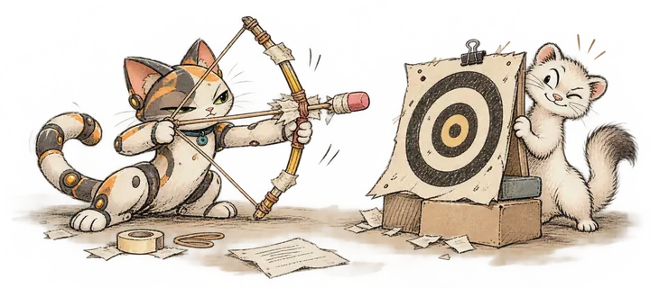

### ✦ Warm-Up · 5 minutes · Two Voices, One Sentence

The SAME sentence could appear in two very different children's books: **“The small monster opened the door.”**

SAMPLE A · Storybook voice

The small monster opened the door.

Serif type · roomy lines · reading begins at the left.

SAMPLE B · Poster-like voice

The small monster  
opened the door.

Bold sans serif · centered · a dramatic pause.

**Think:** A young reader is reading the sentence aloud. Which treatment would you choose for a quiet story page, and why? Could the OTHER treatment work for a different purpose?

TEKS CHECK · 7.12(A) + 7.12(H) · identify and interpret typography

### QUESTION #1

Using Samples A and B in the Warm-Up, name ONE visible typography difference using a correct term. Explain how that difference changes the feeling or reading experience. Then give ONE situation where the other design might be more useful.

Reason from the TWO examples above; your Slides work is not required.ANSWER QUESTION #1 ↗

**Extra Help — notice, name, explain**

Look at serif/sans serif, alignment, weight, line spacing or text size. Choose a real difference that you can SEE. “It looks better” is not enough; explain for whom and why.

### ✎ Learn · Typography Is a Design Tool

**Typography** is how letters and text are selected and arranged to communicate. It helps a reader know *what to read first*, *how to read comfortably*, and *which pages belong to the same book*.

**Vocabulary worth using correctly**

- **Typeface/font:** The appearance of letters; a typeface family such as Georgia or Arial.
- **Serif:** A typeface with small finishing strokes on letters (for example, Georgia).
- **Sans serif:** A typeface without those finishing strokes (for example, Arial).
- **Hierarchy:** Using size, position and weight to show what matters first.
- **Alignment:** Where text lines up: left, center or right.
- **Line spacing:** The space between lines; helps words breathe.
- **Consistency:** Using the same formatting rules for the same type of text across pages.

**Big idea 1 — there is no magic best font.** A serif typeface can feel like a classic story; a sans serif can feel friendly and contemporary. Both can be readable. Choose based on the reader and purpose, not just taste.

**Big idea 2 — jobs need different sizes.** The title might be large and bold. Story sentences should be large enough for a young reader, but not so big that half the story is pushed away.

**Big idea 3 — limit the system.** Start with ONE body-text font and ONE title font (they can be the same). Too many fonts make one book look like unrelated pages.

**Joey:**

“I picked twelve fonts. One for every emotion.”

**Forge:**

“We have four pages.”

**Joey:**

“The emotions are complicated.”

**Forge:**

“So is your font menu.”

### ↗ Practice · Together, 2 minutes · One Tiny Skill

**Skill:** Change the font of ONE piece of text on your existing book's cover slide.

1. Open your **existing Google Slides storybook** and go to its **cover/title slide** (not the Book Plan). Click inside the **story title, author credit, or publisher credit** text box, then select that text.
2. Find the **font dropdown** in the toolbar. Try a readable serif or sans-serif typeface on that selected text.
3. Check: Did ONLY the text you selected change? If not, press **Ctrl+Z** and try again.

Do not redesign your book during Practice. The goal is locating and using ONE formatting control.

Undo ↶Georgia ▾24 ▾**B**☷ Align ▾↕ Line spacing ▾

### ▣ Perform · Build Your Book's Type System

Continue in the **same Google Slides storybook** you opened during Practice. Keep your original story, slide order and illustration placeholders. **Today is for TEXT, not images or proofing.**

1. **Choose a readable body font.** Select one serif OR sans-serif family for story sentences. Test it on one page at presentation size.
2. **Choose title formatting.** Set a larger title font or weight for the cover. Keep author and publisher credits readable but secondary. You may use the same font family in different sizes.
3. **Format two consecutive story pages.** Give both pages the same body font and a similar size, alignment and line spacing. Keep the original wording and illustration placeholders.
4. **Make your rule repeatable.** On the Book Plan or a small working note, write: “Body: ___ font, ___ size, ___ alignment. Cover title: ___ font, ___ size.” Continue formatting additional pages as time allows.

**Goal for today:** At least TWO consistently formatted story pages and an intentionally formatted cover. A complete book, finished images and final proofreading are NOT required.

### ✎ Learn · Hierarchy Without a Font Circus

A reader should notice the **story title** before the small credits. On story pages, the **sentence** needs to be comfortable to read. This is **visual hierarchy**; you can build it with size and bold weight rather than introducing five typefaces.

#### Layout 1 · Calm story opening

**The Secret Door**The door creaked open, just a little.Written by Avery Lee  
Published by Student

#### Layout 2 · Lively cover

The Secret  
DOOR!The door creaked open, just a little.Written by Avery Lee  
Published by Student

Both can work. The choice depends on whether the opening feels quiet or energetic. Notice that the **roles remain clear** in both.

TEKS CHECK · 7.12(H) · apply publication formatting

### QUESTION #2

A student formats the cover title, author credit, and story sentence in the SAME size and weight. Describe TWO specific formatting changes that would create a clearer reading order without adding more than two fonts. Explain what the reader should notice first.

Use the Learn examples, not your own cover.ANSWER QUESTION #2 ↗

**Extra Help — separate the text jobs**

Identify the three text jobs: title, credit and story sentence. Size, weight and placement are each tools. A stronger answer names exact changes and their effect.

### ✎ Learn · Fix the Actual Formatting Problem

Different symptoms need different tools. A font menu changes letter style; font size changes how large letters appear; alignment changes where the text sits; line spacing changes the gap between lines. Those tools are NOT interchangeable.

Problem A · cramped lines

The little monster waited beneath the stairs. The room was silent. Then someone whispered its name.

The letters are readable, but the lines feel crowded.

Problem B · scattered formatting

The little monster waited.

**The room was silent.**

Then someone whispered its name.

A single paragraph uses unrelated sizes, typefaces and alignment.

**Possible fixes:** Problem A: adjust line spacing while preserving a readable size. Problem B: select one body-text rule and apply it consistently. Changing the color would not fix either issue.

TEKS CHECK · 7.12(C) · select the right tool

### QUESTION #3

In Problem A and Problem B above, choose the most useful formatting control for EACH problem. Explain why that control addresses the actual issue, and name ONE tempting change that would NOT solve it.

Two different problems; justify your tool choices.ANSWER QUESTION #3 ↗

**Extra Help — match symptom to tool**

Is the difficulty about distance between lines, letter shape, overall size, or a repeated rule? Use the tool that changes that feature. Avoid “I would make it prettier.”

**Forge:**

“The lines are touching. Which button?”

**Joey:**

“Make every word purple?”

**Forge:**

“How would that make space?”

**Percival.12:**

“I recommend the spacing control. Revolutionary, I know.”

### ✎ Learn · Consistency With a Purpose

A book can use a bold cover title and gentle story text and STILL be consistent: each kind of text follows a rule. Consistency does not mean every word looks identical.

**Three story pages from the same book:** Look at the actual text examples below. They show the SAME kind of writing—normal story sentences, not titles or special messages. Compare the letter shapes and sizes.

PAGE 1 · Georgia · 21 pt

The little monster opened the door.

PAGE 2 · Georgia · 21 pt

A warm light filled the hallway.

PAGE 3 · Arial · 13 pt

Someone had left a note beside the stairs.

All three samples show their fonts at roughly the labeled proportions for the screen. You do not need to build these pages in Slides to compare them.

**Publisher's rule:** Make a small set of choices you can apply repeatedly. Before making exceptions, ask what the exception communicates.

TEKS CHECK · 7.12(A) + 7.12(H) · evaluate a type system

### QUESTION #4

Look at the THREE story-page examples just above. What changes when you reach Page 3? Explain the problem using TWO correct typography terms, then suggest a specific formatting rule that would make all three pages feel like one book. Finally, describe ONE situation where changing the font on purpose could help tell the story.

Use the supplied three-page example; no Slides file needed.ANSWER QUESTION #4 ↗

**Extra Help — consistency is a rule**

Think about font family, size, hierarchy, and what readers assume when a visual pattern changes. Explain why a deliberate exception might communicate something special.

#### 🌡 TEKS Temperature Check

You've practiced **7.12(H)** publication formatting, **7.12(C)** choosing tools and **7.12(A)** using precise technology terms. Help improve our next Learning Guide:

1. Which of these skills can you explain or demonstrate more confidently?
2. Which idea or Slides control is still confusing?
3. What helped you learn today, what didn't, and what should change?

### TEKS & Learning Guide Feedback

Which Priority TEKS did this guide teach clearly? What is still confusing? What worked, what didn't, and what could improve our next guide?

Optional and ungraded. This feedback is not a test score.

SEND TEKS FEEDBACK ↗

### Before you enter Creative Labs

Check each box only when it is true. Complete the FOUR required questions first.

My original Slides book is still in the same file, with story text intact. My cover has intentional title and credit typography. At least two story pages share a consistent, readable body-text system. I answered Questions 1–4 using my own reasoning.

Wayfinder 3040304 · Children's Book Publishing Studio